FJ

# Feidhelm Joyce

Business & Data Analyst  
Boston, MA

linkedin.com/in/feidhelmjoyce  
github.com/FeidhelmJ

DATA MINING FOR BUSINESS ANALYTICS

## K-Nearest Neighbors

← Back to Data Mining for Business Analytics

```
from google.colab import files
from PIL import Image
```

**Linear Algebra**

1. Find a vector x such that $ \begin{pmatrix} 2 & 1 \\ 3 & 2 \end{pmatrix}$ x = $ \begin{pmatrix} 5 \\ 8\end{pmatrix} $

```
question_1 = Image.open("Question_1.jpeg")
question_1
rotated_1 = question_1.rotate(-90)
rotated_1
```

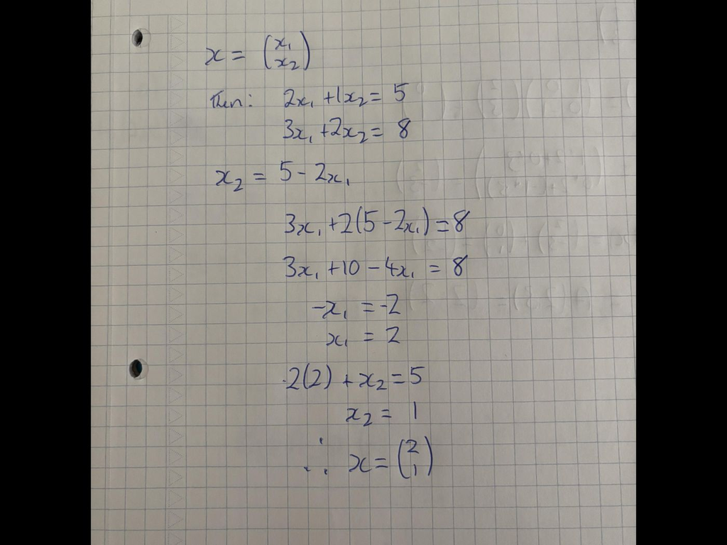

2. An affine transformation A : $\mathbb{R}^2$ → $\mathbb{R}^2$ is given by A(x) = Mx+b, where by M = $ \begin {pmatrix} 1 & 0 \\ 0 & -1 \end {pmatrix} \ $ and b = $ \begin {pmatrix} 0 \\ 1 \end{pmatrix} \ $

(a) Apply this transformation to the point (2,3).

(b) Describe the geometric effect.

- Geometric effect: The transformation A reflects each point across the x-axis and then shifts the result upward by 1 unit.

```
question_2 = Image.open("Question_2.jpeg")
rotated_2 = question_2.rotate(-90)
rotated_2
```

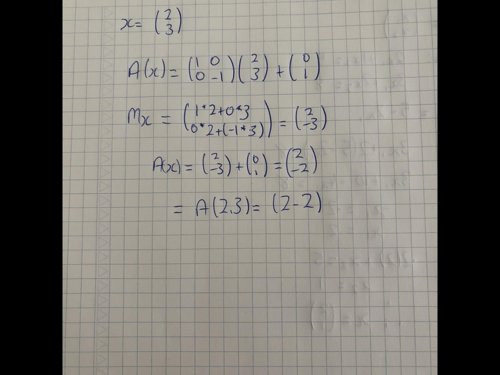

Given two affine transformations

A1(x) = M1x+b1 and A2(x) = M2x+b2

where: $M_1$ = $ \begin {pmatrix} 1 & 2 \\ 0 & 1 \end {pmatrix} \ $ and $b_1$ = $ \begin {pmatrix} 3 \\ -1 \end{pmatrix} \ $ and $M_2$ = = $ \begin {pmatrix} 0 & -1 \\ 1 & 0 \end {pmatrix} \ $ and $b_2$ = $ \begin {pmatrix} 0 \\ 2 \end{pmatrix} \ $

(a) Find the composite affine transformation A2(A1(x)). Specifically, express it in the form MCx+bC.

(b) Then apply this composite transformation to the point p = $ \begin {pmatrix} 1 \\ 1 \end {pmatrix} \ $

```
question_3 = Image.open("Question_3.jpeg")
question_3
```

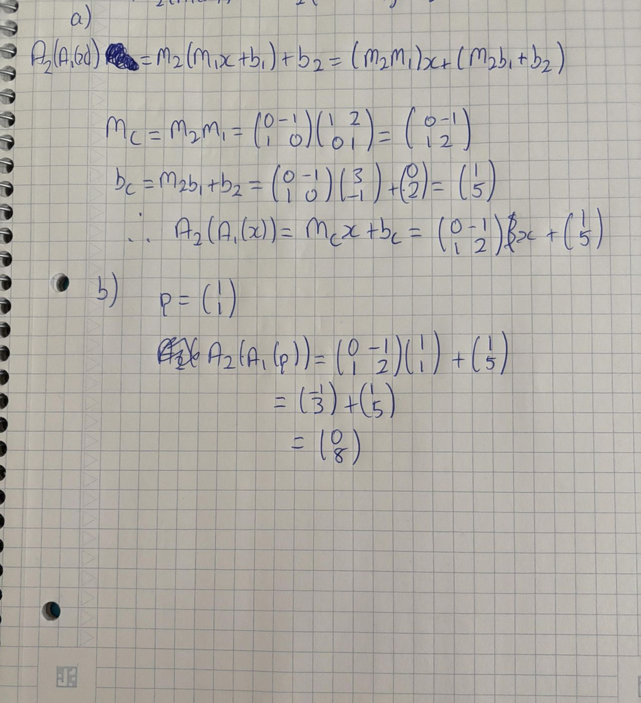

**K-Nearest Neighbors**

Read the dataset spotify_2023 into your environment

```
import pandas as pd
import numpy as np
import matplotlib.pyplot as plt
import seaborn as sns
```

```
spotify_23 = pd.read_csv("spotify-2023.csv", encoding="latin1")
```

```
pd.set_option('display.max_columns', None)
```

Scroll through this dataset, using any method that you prefer, and select any song. If you find a song that you know and like, then select it. If you don’t see any songs that you know, you can just pick any title here (or, even better, you can look up some songs, listen to them, and see if you like any)

```
spotify_23.head(50)
```

|  | track_name | artist(s)_name | artist_count | released_year | released_month | released_day | in_spotify_playlists | in_spotify_charts | streams | in_apple_playlists | in_apple_charts | in_deezer_playlists | in_deezer_charts | in_shazam_charts | bpm | key | mode | danceability_% | valence_% | energy_% | acousticness_% | instrumentalness_% | liveness_% | speechiness_% |
| --- | --- | --- | --- | --- | --- | --- | --- | --- | --- | --- | --- | --- | --- | --- | --- | --- | --- | --- | --- | --- | --- | --- | --- | --- |
| 0 | Seven (feat. Latto) (Explicit Ver.) | Latto, Jung Kook | 2 | 2023 | 7 | 14 | 553 | 147 | 141381703 | 43 | 263 | 45 | 10 | 826 | 125 | B | Major | 80 | 89 | 83 | 31 | 0 | 8 | 4 |
| 1 | LALA | Myke Towers | 1 | 2023 | 3 | 23 | 1474 | 48 | 133716286 | 48 | 126 | 58 | 14 | 382 | 92 | C# | Major | 71 | 61 | 74 | 7 | 0 | 10 | 4 |
| 2 | vampire | Olivia Rodrigo | 1 | 2023 | 6 | 30 | 1397 | 113 | 140003974 | 94 | 207 | 91 | 14 | 949 | 138 | F | Major | 51 | 32 | 53 | 17 | 0 | 31 | 6 |
| 3 | Cruel Summer | Taylor Swift | 1 | 2019 | 8 | 23 | 7858 | 100 | 800840817 | 116 | 207 | 125 | 12 | 548 | 170 | A | Major | 55 | 58 | 72 | 11 | 0 | 11 | 15 |
| 4 | WHERE SHE GOES | Bad Bunny | 1 | 2023 | 5 | 18 | 3133 | 50 | 303236322 | 84 | 133 | 87 | 15 | 425 | 144 | A | Minor | 65 | 23 | 80 | 14 | 63 | 11 | 6 |
| 5 | Sprinter | Dave, Central Cee | 2 | 2023 | 6 | 1 | 2186 | 91 | 183706234 | 67 | 213 | 88 | 17 | 946 | 141 | C# | Major | 92 | 66 | 58 | 19 | 0 | 8 | 24 |
| 6 | Ella Baila Sola | Eslabon Armado, Peso Pluma | 2 | 2023 | 3 | 16 | 3090 | 50 | 725980112 | 34 | 222 | 43 | 13 | 418 | 148 | F | Minor | 67 | 83 | 76 | 48 | 0 | 8 | 3 |
| 7 | Columbia | Quevedo | 1 | 2023 | 7 | 7 | 714 | 43 | 58149378 | 25 | 89 | 30 | 13 | 194 | 100 | F | Major | 67 | 26 | 71 | 37 | 0 | 11 | 4 |
| 8 | fukumean | Gunna | 1 | 2023 | 5 | 15 | 1096 | 83 | 95217315 | 60 | 210 | 48 | 11 | 953 | 130 | C# | Minor | 85 | 22 | 62 | 12 | 0 | 28 | 9 |
| 9 | La Bebe - Remix | Peso Pluma, Yng Lvcas | 2 | 2023 | 3 | 17 | 2953 | 44 | 553634067 | 49 | 110 | 66 | 13 | 339 | 170 | D | Minor | 81 | 56 | 48 | 21 | 0 | 8 | 33 |
| 10 | un x100to | Bad Bunny, Grupo Frontera | 2 | 2023 | 4 | 17 | 2876 | 40 | 505671438 | 41 | 205 | 54 | 12 | 251 | 83 | F# | Minor | 57 | 56 | 72 | 23 | 0 | 27 | 5 |
| 11 | Super Shy | NewJeans | 1 | 2023 | 7 | 7 | 422 | 55 | 58255150 | 37 | 202 | 21 | 5 | 168 | 150 | F | Minor | 78 | 52 | 82 | 18 | 0 | 15 | 7 |
| 12 | Flowers | Miley Cyrus | 1 | 2023 | 1 | 12 | 12211 | 115 | 1316855716 | 300 | 215 | 745 | 58 | 1,021 | 118 | NaN | Major | 71 | 65 | 68 | 6 | 0 | 3 | 7 |
| 13 | Daylight | David Kushner | 1 | 2023 | 4 | 14 | 3528 | 98 | 387570742 | 80 | 156 | 182 | 24 | 1,281 | 130 | D | Minor | 51 | 32 | 43 | 83 | 0 | 9 | 3 |
| 14 | As It Was | Harry Styles | 1 | 2022 | 3 | 31 | 23575 | 130 | 2513188493 | 403 | 198 | 863 | 46 | NaN | 174 | F# | Minor | 52 | 66 | 73 | 34 | 0 | 31 | 6 |
| 15 | Kill Bill | SZA | 1 | 2022 | 12 | 8 | 8109 | 77 | 1163093654 | 183 | 162 | 161 | 12 | 187 | 89 | G# | Major | 64 | 43 | 73 | 5 | 17 | 16 | 4 |
| 16 | Cupid - Twin Ver. | Fifty Fifty | 1 | 2023 | 2 | 24 | 2942 | 77 | 496795686 | 91 | 212 | 78 | 6 | 0 | 120 | B | Minor | 78 | 76 | 59 | 43 | 0 | 34 | 3 |
| 17 | What Was I Made For? [From The Motion Picture ... | Billie Eilish | 1 | 2023 | 7 | 13 | 873 | 104 | 30546883 | 80 | 227 | 95 | 24 | 1,173 | 78 | NaN | Major | 44 | 14 | 9 | 96 | 0 | 10 | 3 |
| 18 | Classy 101 | Feid, Young Miko | 2 | 2023 | 3 | 31 | 2610 | 40 | 335222234 | 43 | 100 | 54 | 14 | 187 | 100 | B | Major | 86 | 67 | 66 | 14 | 0 | 12 | 16 |
| 19 | Like Crazy | Jimin | 1 | 2023 | 3 | 24 | 596 | 68 | 363369738 | 8 | 104 | 23 | 2 | 29 | 120 | G | Major | 63 | 36 | 73 | 0 | 0 | 36 | 4 |
| 20 | LADY GAGA | Gabito Ballesteros, Junior H, Peso Pluma | 3 | 2023 | 6 | 22 | 332 | 26 | 86444842 | 11 | 163 | 10 | 4 | 0 | 140 | F | Minor | 65 | 87 | 74 | 22 | 0 | 42 | 4 |
| 21 | I Can See You (Taylorï¿½ï¿½ï¿½s Version) (From... | Taylor Swift | 1 | 2023 | 7 | 7 | 516 | 38 | 52135248 | 73 | 119 | 42 | 1 | 150 | 123 | F# | Major | 69 | 82 | 76 | 6 | 0 | 6 | 3 |
| 22 | I Wanna Be Yours | Arctic Monkeys | 1 | 2013 | 1 | 1 | 12859 | 110 | 1297026226 | 24 | 98 | 582 | 2 | 73 | 135 | NaN | Minor | 48 | 44 | 42 | 12 | 2 | 11 | 3 |
| 23 | Peso Pluma: Bzrp Music Sessions, Vol. 55 | Bizarrap, Peso Pluma | 2 | 2023 | 5 | 31 | 1313 | 40 | 200647221 | 17 | 152 | 32 | 11 | 139 | 133 | F | Minor | 85 | 81 | 67 | 26 | 0 | 12 | 5 |
| 24 | Popular (with Playboi Carti & Madonna) - The I... | The Weeknd, Madonna, Playboi Carti | 3 | 2023 | 6 | 2 | 1945 | 87 | 115364561 | 74 | 182 | 87 | 14 | 1,093 | 99 | C# | Major | 85 | 83 | 68 | 7 | 0 | 36 | 20 |
| 25 | SABOR FRESA | Fuerza Regida | 1 | 2023 | 6 | 22 | 250 | 26 | 78300654 | 16 | 149 | 10 | 5 | 168 | 130 | G | Minor | 79 | 96 | 86 | 9 | 0 | 9 | 9 |
| 26 | Calm Down (with Selena Gomez) | Rï¿½ï¿½ma, Selena G | 2 | 2022 | 3 | 25 | 7112 | 77 | 899183384 | 202 | 119 | 318 | 38 | 96 | 107 | B | Major | 80 | 82 | 80 | 43 | 0 | 14 | 4 |
| 27 | MOJABI GHOST | Tainy, Bad Bunny | 2 | 2023 | 6 | 29 | 859 | 40 | 61245289 | 35 | 109 | 41 | 14 | 211 | 122 | F# | Minor | 81 | 74 | 71 | 14 | 0 | 56 | 4 |
| 28 | Last Night | Morgan Wallen | 1 | 2023 | 1 | 31 | 2420 | 19 | 429829812 | 52 | 107 | 15 | 1 | 325 | 204 | F# | Major | 52 | 52 | 68 | 46 | 0 | 15 | 4 |
| 29 | Dance The Night (From Barbie The Album) | Dua Lipa | 1 | 2023 | 5 | 25 | 2988 | 101 | 127408954 | 0 | 0 | 143 | 38 | 0 | 110 | B | Minor | 67 | 78 | 85 | 2 | 0 | 33 | 5 |
| 30 | Rush | Troye Sivan | 1 | 2023 | 7 | 13 | 864 | 78 | 22581161 | 71 | 135 | 50 | 1 | 294 | 126 | F | Minor | 74 | 35 | 84 | 0 | 0 | 11 | 6 |
| 31 | TULUM | Peso Pluma, Grupo Frontera | 2 | 2023 | 6 | 28 | 266 | 34 | 52294266 | 20 | 185 | 13 | 8 | 197 | 168 | F# | Major | 56 | 63 | 87 | 39 | 0 | 11 | 5 |
| 32 | Creepin' | The Weeknd, 21 Savage, Metro Boomin | 3 | 2022 | 12 | 2 | 6036 | 88 | 843957510 | 113 | 149 | 245 | 23 | 27 | 98 | C# | Minor | 71 | 17 | 61 | 36 | 0 | 8 | 5 |
| 33 | Anti-Hero | Taylor Swift | 1 | 2022 | 10 | 21 | 9082 | 56 | 999748277 | 242 | 142 | 165 | 9 | 310 | 97 | E | Major | 64 | 51 | 63 | 12 | 0 | 19 | 5 |
| 34 | TQG | Karol G, Shakira | 2 | 2023 | 2 | 23 | 4284 | 49 | 618990393 | 115 | 123 | 184 | 18 | 354 | 180 | E | Minor | 72 | 61 | 63 | 67 | 0 | 9 | 28 |
| 35 | Los del Espacio | Big One, Duki, Lit Killah, Maria Becerra, FMK,... | 8 | 2023 | 6 | 1 | 1150 | 31 | 123122413 | 22 | 33 | 34 | 7 | 184 | 120 | NaN | Major | 81 | 63 | 68 | 11 | 0 | 11 | 4 |
| 36 | Frï¿½ï¿½gil (feat. Grupo Front | Yahritza Y Su Esencia, Grupo Frontera | 2 | 2023 | 4 | 7 | 672 | 34 | 188933502 | 19 | 108 | 24 | 9 | 212 | 150 | F# | Major | 61 | 39 | 73 | 37 | 0 | 11 | 3 |
| 37 | Blank Space | Taylor Swift | 1 | 2014 | 1 | 1 | 11434 | 53 | 1355959075 | 154 | 123 | 410 | 2 | 81 | 96 | F | Major | 75 | 57 | 68 | 9 | 0 | 13 | 6 |
| 38 | Style | Taylor Swift | 1 | 2014 | 1 | 1 | 7830 | 42 | 786181836 | 94 | 111 | 151 | 4 | 82 | 95 | D | Major | 60 | 48 | 79 | 0 | 0 | 12 | 4 |
| 39 | TQM | Fuerza Regida | 1 | 2023 | 5 | 19 | 584 | 28 | 176553476 | 16 | 159 | 15 | 6 | 100 | 125 | F | Minor | 79 | 96 | 85 | 27 | 0 | 11 | 6 |
| 40 | El Azul | Junior H, Peso Pluma | 2 | 2023 | 2 | 10 | 692 | 25 | 354495408 | 10 | 107 | 6 | 3 | 62 | 144 | A | Minor | 56 | 84 | 65 | 23 | 0 | 10 | 6 |
| 41 | Sunflower - Spider-Man: Into the Spider-Verse | Post Malone, Swae Lee | 2 | 2018 | 10 | 9 | 24094 | 78 | 2808096550 | 372 | 117 | 843 | 4 | 69 | 90 | D | Major | 76 | 91 | 50 | 54 | 0 | 7 | 5 |
| 42 | I'm Good (Blue) | Bebe Rexha, David Guetta | 2 | 2022 | 8 | 26 | 12482 | 80 | 1109433169 | 291 | 184 | 537 | 45 | 727 | 128 | G | Minor | 56 | 38 | 97 | 4 | 0 | 35 | 4 |
| 43 | See You Again | Tyler, The Creator, Kali Uchis | 3 | 2017 | 7 | 21 | 13387 | 64 | 1047101291 | 77 | 58 | 247 | 1 | 311 | 79 | F# | Major | 56 | 58 | 56 | 37 | 0 | 11 | 10 |
| 44 | Barbie World (with Aqua) [From Barbie The Album] | Nicki Minaj, Aqua, Ice Spice | 3 | 2023 | 6 | 23 | 1117 | 80 | 65156199 | 82 | 145 | 65 | 16 | 1,133 | 144 | NaN | Major | 77 | 75 | 58 | 52 | 0 | 23 | 25 |
| 45 | Angels Like You | Miley Cyrus | 1 | 2020 | 11 | 27 | 3372 | 19 | 570515054 | 65 | 48 | 138 | 1 | 102 | 122 | F | Major | 67 | 49 | 64 | 10 | 0 | 10 | 3 |
| 46 | I Ain't Worried | OneRepublic | 1 | 2022 | 5 | 13 | 8431 | 76 | 1085685420 | 241 | 127 | 458 | 37 | 332 | 140 | NaN | Major | 71 | 82 | 81 | 11 | 0 | 6 | 5 |
| 47 | Die For You | The Weeknd | 1 | 2016 | 11 | 24 | 2483 | 59 | 1647990401 | 68 | 21 | 24 | 0 | 259 | 134 | C# | Minor | 59 | 51 | 52 | 9 | 0 | 15 | 7 |
| 48 | Starboy | The Weeknd, Daft Punk | 2 | 2016 | 9 | 21 | 29536 | 79 | 2565529693 | 281 | 137 | 2,445 | 1 | 140 | 186 | G | Major | 68 | 49 | 59 | 16 | 0 | 13 | 28 |
| 49 | Die For You - Remix | Ariana Grande, The Weeknd | 2 | 2023 | 2 | 24 | 3408 | 47 | 518745108 | 87 | 86 | 74 | 1 | 16 | 67 | C# | Minor | 53 | 50 | 53 | 23 | 0 | 44 | 7 |

What song did you pick? In a sentence or two, why did you pick this song?

- I chose 'I Wanna Be Yours' by the Artic Monkeys. I've been listening to the Artic Monkeys a lot of late and this is my favorite song of theirs.
4. What values does your song have for the following categories:

Categories:

```
danceability  - 48%
energy - 42%
speechiness - 3%
acousticness - 12%
liveness - 11%
valence - 44%
BPM - 135
```

```
spotify_23.iloc[22]
```

|  | 22 |
| --- | --- |
| track_name | I Wanna Be Yours |
| artist(s)_name | Arctic Monkeys |
| artist_count | 1 |
| released_year | 2013 |
| released_month | 1 |
| released_day | 1 |
| in_spotify_playlists | 12859 |
| in_spotify_charts | 110 |
| streams | 1297026226 |
| in_apple_playlists | 24 |
| in_apple_charts | 98 |
| in_deezer_playlists | 582 |
| in_deezer_charts | 2 |
| in_shazam_charts | 73 |
| bpm | 135 |
| key | NaN |
| mode | Minor |
| danceability_% | 48 |
| valence_% | 44 |
| energy_% | 42 |
| acousticness_% | 12 |
| instrumentalness_% | 2 |
| liveness_% | 11 |
| speechiness_% | 3 |

Extract the row that contains info for your song from spotify_2023.csv. Verify that your song is now stored as its own dataframe (if it’s not currently a dataframe, convert it into one now).

```
favorite_song = spotify_23.iloc[[22]]
```

```
type(favorite_song)
```

```
pandas.core.frame.DataFrame
```

Now, read spotify.csv dataset into your environment. Call the describe() function on your dataset and show the results.

```
spotify = pd.read_csv("spotify.csv")
```

```
spotify.head()
```

|  | Unnamed: 0 | acousticness | danceability | duration_ms | energy | instrumentalness | key | liveness | loudness | mode | speechiness | tempo | time_signature | valence | target | song_title | artist |
| --- | --- | --- | --- | --- | --- | --- | --- | --- | --- | --- | --- | --- | --- | --- | --- | --- | --- |
| 0 | 0 | 0.0102 | 0.833 | 204600 | 0.434 | 0.021900 | 2 | 0.1650 | -8.795 | 1 | 0.4310 | 150.062 | 4.0 | 0.286 | 1 | Mask Off | Future |
| 1 | 1 | 0.1990 | 0.743 | 326933 | 0.359 | 0.006110 | 1 | 0.1370 | -10.401 | 1 | 0.0794 | 160.083 | 4.0 | 0.588 | 1 | Redbone | Childish Gambino |
| 2 | 2 | 0.0344 | 0.838 | 185707 | 0.412 | 0.000234 | 2 | 0.1590 | -7.148 | 1 | 0.2890 | 75.044 | 4.0 | 0.173 | 1 | Xanny Family | Future |
| 3 | 3 | 0.6040 | 0.494 | 199413 | 0.338 | 0.510000 | 5 | 0.0922 | -15.236 | 1 | 0.0261 | 86.468 | 4.0 | 0.230 | 1 | Master Of None | Beach House |
| 4 | 4 | 0.1800 | 0.678 | 392893 | 0.561 | 0.512000 | 5 | 0.4390 | -11.648 | 0 | 0.0694 | 174.004 | 4.0 | 0.904 | 1 | Parallel Lines | Junior Boys |

```
spotify.describe()
```

|  | Unnamed: 0 | acousticness | danceability | duration_ms | energy | instrumentalness | key | liveness | loudness | mode | speechiness | tempo | time_signature | valence | target |
| --- | --- | --- | --- | --- | --- | --- | --- | --- | --- | --- | --- | --- | --- | --- | --- |
| count | 2017.000000 | 2017.000000 | 2017.000000 | 2.017000e+03 | 2017.000000 | 2017.000000 | 2017.000000 | 2017.000000 | 2017.000000 | 2017.000000 | 2017.000000 | 2017.000000 | 2017.000000 | 2017.000000 | 2017.000000 |
| mean | 1008.000000 | 0.187590 | 0.618422 | 2.463062e+05 | 0.681577 | 0.133286 | 5.342588 | 0.190844 | -7.085624 | 0.612295 | 0.092664 | 121.603272 | 3.968270 | 0.496815 | 0.505702 |
| std | 582.402066 | 0.259989 | 0.161029 | 8.198181e+04 | 0.210273 | 0.273162 | 3.648240 | 0.155453 | 3.761684 | 0.487347 | 0.089931 | 26.685604 | 0.255853 | 0.247195 | 0.500091 |
| min | 0.000000 | 0.000003 | 0.122000 | 1.604200e+04 | 0.014800 | 0.000000 | 0.000000 | 0.018800 | -33.097000 | 0.000000 | 0.023100 | 47.859000 | 1.000000 | 0.034800 | 0.000000 |
| 25% | 504.000000 | 0.009630 | 0.514000 | 2.000150e+05 | 0.563000 | 0.000000 | 2.000000 | 0.092300 | -8.394000 | 0.000000 | 0.037500 | 100.189000 | 4.000000 | 0.295000 | 0.000000 |
| 50% | 1008.000000 | 0.063300 | 0.631000 | 2.292610e+05 | 0.715000 | 0.000076 | 6.000000 | 0.127000 | -6.248000 | 1.000000 | 0.054900 | 121.427000 | 4.000000 | 0.492000 | 1.000000 |
| 75% | 1512.000000 | 0.265000 | 0.738000 | 2.703330e+05 | 0.846000 | 0.054000 | 9.000000 | 0.247000 | -4.746000 | 1.000000 | 0.108000 | 137.849000 | 4.000000 | 0.691000 | 1.000000 |
| max | 2016.000000 | 0.995000 | 0.984000 | 1.004627e+06 | 0.998000 | 0.976000 | 11.000000 | 0.969000 | -0.307000 | 1.000000 | 0.816000 | 219.331000 | 5.000000 | 0.992000 | 1.000000 |

What type of variable is target? If target is not currently a categorical variable, convert it into a categorical variable. It will be our response variable in this model. Target tells us whether George, the person who uploaded this dataset, liked the song. 1 means that George liked it, and 0 means that he did not.

- Target is currently listed as a numeric variable, changed variable type below.

```
spotify.info()
```

```
<class 'pandas.core.frame.DataFrame'>
RangeIndex: 2017 entries, 0 to 2016
Data columns (total 17 columns):
 #   Column            Non-Null Count  Dtype
---  ------            --------------  -----
 0   Unnamed: 0        2017 non-null   int64
 1   acousticness      2017 non-null   float64
 2   danceability      2017 non-null   float64
 3   duration_ms       2017 non-null   int64
 4   energy            2017 non-null   float64
 5   instrumentalness  2017 non-null   float64
 6   key               2017 non-null   int64
 7   liveness          2017 non-null   float64
 8   loudness          2017 non-null   float64
 9   mode              2017 non-null   int64
 10  speechiness       2017 non-null   float64
 11  tempo             2017 non-null   float64
 12  time_signature    2017 non-null   float64
 13  valence           2017 non-null   float64
 14  target            2017 non-null   int64
 15  song_title        2017 non-null   object
 16  artist            2017 non-null   object
dtypes: float64(10), int64(5), object(2)
memory usage: 268.0+ KB
```

```
spotify['target'] = spotify['target'].astype('category')
```

```
spotify.info()
```

```
<class 'pandas.core.frame.DataFrame'>
RangeIndex: 2017 entries, 0 to 2016
Data columns (total 17 columns):
 #   Column            Non-Null Count  Dtype
---  ------            --------------  -----
 0   Unnamed: 0        2017 non-null   int64
 1   acousticness      2017 non-null   float64
 2   danceability      2017 non-null   float64
 3   duration_ms       2017 non-null   int64
 4   energy            2017 non-null   float64
 5   instrumentalness  2017 non-null   float64
 6   key               2017 non-null   int64
 7   liveness          2017 non-null   float64
 8   loudness          2017 non-null   float64
 9   mode              2017 non-null   int64
 10  speechiness       2017 non-null   float64
 11  tempo             2017 non-null   float64
 12  time_signature    2017 non-null   float64
 13  valence           2017 non-null   float64
 14  target            2017 non-null   category
 15  song_title        2017 non-null   object
 16  artist            2017 non-null   object
dtypes: category(1), float64(10), int64(4), object(2)
memory usage: 254.3+ KB
```

What unique values does the target variable have? For each of these outcome values, find out how many records in the dataset have that value, and state it here.

- 1 (George liked the song) - 1,020 values
- 0 (George disliked the song) - 997 values

```
spotify['target'].unique()
```

```
[1, 0]
Categories (2, int64): [0, 1]
```

```
spotify['target'].value_counts()
```

| target | count |
| --- | --- |
| 1 | 1020 |
| 0 | 997 |

9. Are there any NAs in this dataset? Show the code that you used to find this out. If there are any NA values in any particular column, replace them with the median value for that column.

```
spotify.isna().sum()
```

|  | 0 |
| --- | --- |
| Unnamed: 0 | 0 |
| acousticness | 0 |
| danceability | 0 |
| duration_ms | 0 |
| energy | 0 |
| instrumentalness | 0 |
| key | 0 |
| liveness | 0 |
| loudness | 0 |
| mode | 0 |
| speechiness | 0 |
| tempo | 0 |
| time_signature | 0 |
| valence | 0 |
| target | 0 |
| song_title | 0 |
| artist | 0 |

Data Engineering

Currently, the values for danceability, energy, speechiness, valence, acousticness, and liveness are stored as whole numbers that represent percentage values. Change this by converting those values into decimals (for instance, if you have a value of 74, it needs to become 0.74). Note: if you’re not sure which version of the data is not yet in decimal format, you can very quickly solve this by looking at the data.

```
spotify_23.head()
```

|  | track_name | artist(s)_name | artist_count | released_year | released_month | released_day | in_spotify_playlists | in_spotify_charts | streams | in_apple_playlists | in_apple_charts | in_deezer_playlists | in_deezer_charts | in_shazam_charts | bpm | key | mode | danceability_% | valence_% | energy_% | acousticness_% | instrumentalness_% | liveness_% | speechiness_% |
| --- | --- | --- | --- | --- | --- | --- | --- | --- | --- | --- | --- | --- | --- | --- | --- | --- | --- | --- | --- | --- | --- | --- | --- | --- |
| 0 | Seven (feat. Latto) (Explicit Ver.) | Latto, Jung Kook | 2 | 2023 | 7 | 14 | 553 | 147 | 141381703 | 43 | 263 | 45 | 10 | 826 | 125 | B | Major | 80 | 89 | 83 | 31 | 0 | 8 | 4 |
| 1 | LALA | Myke Towers | 1 | 2023 | 3 | 23 | 1474 | 48 | 133716286 | 48 | 126 | 58 | 14 | 382 | 92 | C# | Major | 71 | 61 | 74 | 7 | 0 | 10 | 4 |
| 2 | vampire | Olivia Rodrigo | 1 | 2023 | 6 | 30 | 1397 | 113 | 140003974 | 94 | 207 | 91 | 14 | 949 | 138 | F | Major | 51 | 32 | 53 | 17 | 0 | 31 | 6 |
| 3 | Cruel Summer | Taylor Swift | 1 | 2019 | 8 | 23 | 7858 | 100 | 800840817 | 116 | 207 | 125 | 12 | 548 | 170 | A | Major | 55 | 58 | 72 | 11 | 0 | 11 | 15 |
| 4 | WHERE SHE GOES | Bad Bunny | 1 | 2023 | 5 | 18 | 3133 | 50 | 303236322 | 84 | 133 | 87 | 15 | 425 | 144 | A | Minor | 65 | 23 | 80 | 14 | 63 | 11 | 6 |

```
columns_to_round = ['danceability_%', 'energy_%', 'speechiness_%',
                 'valence_%', 'acousticness_%', 'liveness_%']

spotify_23[columns_to_round] = spotify_23[columns_to_round]/100
```

```
spotify_23.head()
```

|  | track_name | artist(s)_name | artist_count | released_year | released_month | released_day | in_spotify_playlists | in_spotify_charts | streams | in_apple_playlists | in_apple_charts | in_deezer_playlists | in_deezer_charts | in_shazam_charts | bpm | key | mode | danceability_% | valence_% | energy_% | acousticness_% | instrumentalness_% | liveness_% | speechiness_% |
| --- | --- | --- | --- | --- | --- | --- | --- | --- | --- | --- | --- | --- | --- | --- | --- | --- | --- | --- | --- | --- | --- | --- | --- | --- |
| 0 | Seven (feat. Latto) (Explicit Ver.) | Latto, Jung Kook | 2 | 2023 | 7 | 14 | 553 | 147 | 141381703 | 43 | 263 | 45 | 10 | 826 | 125 | B | Major | 0.80 | 0.89 | 0.83 | 0.31 | 0 | 0.08 | 0.04 |
| 1 | LALA | Myke Towers | 1 | 2023 | 3 | 23 | 1474 | 48 | 133716286 | 48 | 126 | 58 | 14 | 382 | 92 | C# | Major | 0.71 | 0.61 | 0.74 | 0.07 | 0 | 0.10 | 0.04 |
| 2 | vampire | Olivia Rodrigo | 1 | 2023 | 6 | 30 | 1397 | 113 | 140003974 | 94 | 207 | 91 | 14 | 949 | 138 | F | Major | 0.51 | 0.32 | 0.53 | 0.17 | 0 | 0.31 | 0.06 |
| 3 | Cruel Summer | Taylor Swift | 1 | 2019 | 8 | 23 | 7858 | 100 | 800840817 | 116 | 207 | 125 | 12 | 548 | 170 | A | Major | 0.55 | 0.58 | 0.72 | 0.11 | 0 | 0.11 | 0.15 |
| 4 | WHERE SHE GOES | Bad Bunny | 1 | 2023 | 5 | 18 | 3133 | 50 | 303236322 | 84 | 133 | 87 | 15 | 425 | 144 | A | Minor | 0.65 | 0.23 | 0.80 | 0.14 | 63 | 0.11 | 0.06 |

```
spotify_23.info()
```

```
<class 'pandas.core.frame.DataFrame'>
RangeIndex: 953 entries, 0 to 952
Data columns (total 24 columns):
 #   Column                Non-Null Count  Dtype
---  ------                --------------  -----
 0   track_name            953 non-null    object
 1   artist(s)_name        953 non-null    object
 2   artist_count          953 non-null    int64
 3   released_year         953 non-null    int64
 4   released_month        953 non-null    int64
 5   released_day          953 non-null    int64
 6   in_spotify_playlists  953 non-null    int64
 7   in_spotify_charts     953 non-null    int64
 8   streams               953 non-null    object
 9   in_apple_playlists    953 non-null    int64
 10  in_apple_charts       953 non-null    int64
 11  in_deezer_playlists   953 non-null    object
 12  in_deezer_charts      953 non-null    int64
 13  in_shazam_charts      903 non-null    object
 14  bpm                   953 non-null    int64
 15  key                   858 non-null    object
 16  mode                  953 non-null    object
 17  danceability_%        953 non-null    float64
 18  valence_%             953 non-null    float64
 19  energy_%              953 non-null    float64
 20  acousticness_%        953 non-null    float64
 21  instrumentalness_%    953 non-null    int64
 22  liveness_%            953 non-null    float64
 23  speechiness_%         953 non-null    float64
dtypes: float64(6), int64(11), object(7)
memory usage: 178.8+ KB
```

Change the names of your column variables for danceability, energy, speechiness, valence, acousticness, and liveness so that they match the names in spotify. Also, change the BPM variable name for your song to tempo . The names must become a perfect match, so watch out for things like capitalization, punctuation, formatting, etc.

```
spotify_23 = spotify_23.rename(columns={'danceability_%': 'danceability', 'energy_%': 'energy', 'speechiness_%': 'speechiness', 'valence_%': 'valence', 'acousticness_%': 'acousticness', 'liveness_%': 'liveness', 'bpm': 'tempo'})
```

```
favorite_song = favorite_song.rename(columns={'danceability_%': 'danceability', 'energy_%': 'energy', 'speechiness_%': 'speechiness', 'valence_%': 'valence', 'acousticness_%': 'acousticness', 'liveness_%': 'liveness', 'bpm' : 'tempo'})
```

```
columns_to_convert = ['danceability', 'energy', 'speechiness', 'valence', 'acousticness', 'liveness']
favorite_song[columns_to_convert] = favorite_song[columns_to_convert] / 100
```

```
favorite_song.head()
```

|  | track_name | artist(s)_name | artist_count | released_year | released_month | released_day | in_spotify_playlists | in_spotify_charts | streams | in_apple_playlists | in_apple_charts | in_deezer_playlists | in_deezer_charts | in_shazam_charts | tempo | key | mode | danceability | valence | energy | acousticness | instrumentalness_% | liveness | speechiness |
| --- | --- | --- | --- | --- | --- | --- | --- | --- | --- | --- | --- | --- | --- | --- | --- | --- | --- | --- | --- | --- | --- | --- | --- | --- |
| 22 | I Wanna Be Yours | Arctic Monkeys | 1 | 2013 | 1 | 1 | 12859 | 110 | 1297026226 | 24 | 98 | 582 | 2 | 73 | 135 | NaN | Minor | 0.48 | 0.44 | 0.42 | 0.12 | 2 | 0.11 | 0.03 |

Partition the spotify dataset into training (60%) and validation (40%) sets. Next, we will do some variable selection.

```
from sklearn.model_selection import train_test_split
```

```
training_df, validation_df = train_test_split(spotify, test_size=0.4, random_state=789)
```

```
len(training_df)
```

```
1210
```

Using your training set, perform a series of two-sample t-tests to compare the numeric values for songs that George liked vs ones that he did not like. Focus only on these seven variables: danceability, tempo, energy, speechiness, valence, acousticness, and liveness.

```
from scipy.stats import ttest_ind
```

```
spotify.columns
```

```
Index(['Unnamed: 0', 'acousticness', 'danceability', 'duration_ms', 'energy',
       'instrumentalness', 'key', 'liveness', 'loudness', 'mode',
       'speechiness', 'tempo', 'time_signature', 'valence', 'target',
       'song_title', 'artist'],
      dtype='object')
```

```
variables = ['danceability', 'tempo', 'energy', 'speechiness', 'valence', 'acousticness', 'liveness']
```

```
for var in variables:
  liked = training_df[training_df['target'] == 1][var]
  disliked = training_df[training_df['target'] == 0][var]
  t_stat, p_value = ttest_ind(liked, disliked, equal_var=False)
  print(f"Variable: {var}")
  print(f"t-statistic: {t_stat:.3f}")
  print(f"p-value: {p_value:.8f}")
  print()
```

```
Variable: danceability
t-statistic: 5.853
p-value: 0.00000001

Variable: tempo
t-statistic: 1.886
p-value: 0.05952262

Variable: energy
t-statistic: 2.263
p-value: 0.02383691

Variable: speechiness
t-statistic: 4.952
p-value: 0.00000084

Variable: valence
t-statistic: 4.039
p-value: 0.00005706

Variable: acousticness
t-statistic: -5.487
p-value: 0.00000005

Variable: liveness
t-statistic: 1.782
p-value: 0.07499014
```

Which variables show a significant difference? For any variables for which there is not a significant difference between the ’like’ and ’dislike’ values, remove them entirely from your data.

[output not shown]

```
training_df = training_df.drop(columns=['tempo', 'liveness'])
validation_df = validation_df.drop(columns=['tempo', 'liveness'])
```

In a sentence or two, why might it make sense to remove variables from a knn model when those variables’ values are very similar for both outcome classes? For this two-sample ttest, there’s no need to first check the data for normality; given the sample size and the distribution of the values, it will be robust to non-normality.

- It makes sense to remove variables whose values are very similar for both outcome classes because they do not help the KNN model distinguish between songs that George liked and those he did not — such variables add noise without improving predictive power.
- In this case, since the two-sample t-test shows no significant difference between classes, those variables likely provide little discriminative information, so removing them simplifies the model without hurting accuracy.

Normalize your data using the StandardScaler() function.

```
from sklearn.preprocessing import StandardScaler
```

```
features = ['danceability', 'energy', 'speechiness', 'valence', 'acousticness']
```

```
scaler = StandardScaler()
```

```
scaler.fit(training_df[features])
```

```
StandardScaler()
```

```
training_data_scaled = training_df.copy()
validation_data_scaled = validation_df.copy()
```

```
training_data_scaled[features] = scaler.transform(training_df[features])
validation_data_scaled[features] = scaler.transform(validation_df[features])
```

```
training_data_scaled[features].describe().round(2)
```

|  | danceability | energy | speechiness | valence | acousticness |
| --- | --- | --- | --- | --- | --- |
| count | 1210.00 | 1210.00 | 1210.00 | 1210.00 | 1210.00 |
| mean | -0.00 | 0.00 | -0.00 | 0.00 | -0.00 |
| std | 1.00 | 1.00 | 1.00 | 1.00 | 1.00 |
| min | -3.15 | -3.25 | -0.78 | -1.88 | -0.71 |
| 25% | -0.65 | -0.58 | -0.62 | -0.82 | -0.67 |
| 50% | 0.08 | 0.16 | -0.42 | -0.03 | -0.47 |
| 75% | 0.74 | 0.78 | 0.20 | 0.80 | 0.24 |
| max | 2.27 | 1.49 | 8.17 | 1.98 | 3.18 |

Using a k-value of 7, generate a predicted classification for your song – Will George like it or not?

– What outcome did the model predict? - George did not like the song.

– Also, what were your song’s 7 nearest neighbors?

– List their titles, artists, and outcome classes. Be sure to show their outcome classes in your write-up.

As you perform this step, be sure that the variable names for your song are formatted the same way (spelling, capitalization, etc.) as the ones in the spotify dataset.

```
from sklearn.neighbors import KNeighborsClassifier
```

```
target = 'target'
```

```
knn = KNeighborsClassifier(n_neighbors=7)
knn.fit(training_data_scaled[features], training_data_scaled[target])
```

```
KNeighborsClassifier(n_neighbors=7)
```

```
favorite_song_scaled = favorite_song.copy()
```

```
favorite_song_scaled[features] = scaler.transform(favorite_song[features])
```

```
prediction = knn.predict(favorite_song_scaled[features])
prediction
```

```
array([0])
```

```
distances, indices = knn.kneighbors(favorite_song_scaled[features])
```

```
nearest_neighbors = training_data_scaled.iloc[indices[0]][['song_title','artist','target']]
nearest_neighbors
```

|  | song_title | artist | target |
| --- | --- | --- | --- |
| 889 | All I Wanna Do | The Beach Boys | 1 |
| 1047 | Real Thing | Zac Brown Band | 0 |
| 1221 | Do I Wanna Know? | Arctic Monkeys | 0 |
| 1707 | Without Me | Kina Grannis | 0 |
| 972 | Gonna Die | Autre Ne Veut | 1 |
| 1287 | More Than Conquerors (Radio Version) | Steven Curtis Chapman | 0 |
| 1944 | (Everything I Do) I Do It For You | Bryan Adams | 0 |

Use your validation set to help you determine an optimal k-value.

```
from sklearn.metrics import accuracy_score
```

```
k_values = range(1, 26)
accuracies = []
```

```
for k in k_values:
  knn = KNeighborsClassifier(n_neighbors=k)
  knn.fit(training_data_scaled[features], training_data_scaled[target])
  predictors = knn.predict(validation_data_scaled[features])
  accuracy = accuracy_score(validation_data_scaled[target], predictors)
  accuracies.append(accuracy)
```

```
best_k = k_values[np.argmax(accuracies)]
best_accuracy = max(accuracies)
best_accuracy
print(f"Best k: {best_k}, Validation Accuracy: {best_accuracy:.4f}")
```

```
Best k: 25, Validation Accuracy: 0.6493
```

Make a scatterplot with the various k values that you used in the previous step on your x-axis, and the accuracy metrics on the y-axis.

```
plt.figure(figsize=(8, 5))
plt.plot(k_values, accuracies, color = 'blue', alpha = 0.5, label = 'Validation Accuracy')
plt.scatter(k_values, accuracies, color = 'red', label = 'K values')
plt.xlabel('K Values')
plt.ylabel('Validation Accuracy')
plt.title('Validation Accuracy vs. K Values')
plt.show()
```

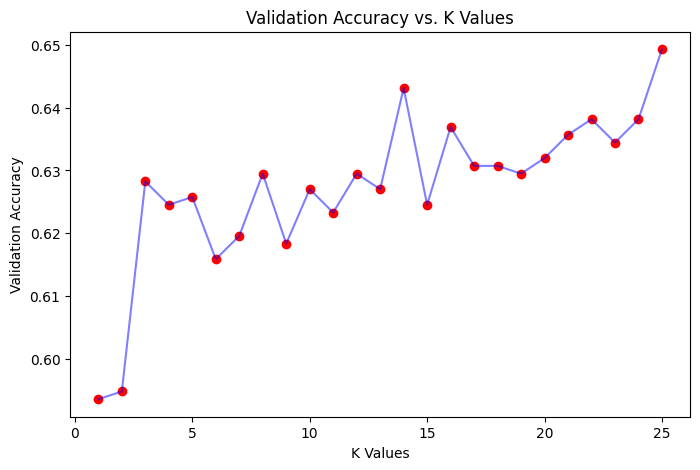

Re-run the knn function with the optimal k-value that you found previously. What result did you obtain? Was it different from the result you saw when you first ran the knn function? Also, what were the outcome classes for each of your song’s k-nearest neighbors? Be sure to show their outcome classes in your write-up.

```
knn_final = KNeighborsClassifier(n_neighbors=best_k)
knn_final.fit(training_data_scaled[features], training_data_scaled[target])
```

```
KNeighborsClassifier(n_neighbors=25)
```

```
final_prediction = knn_final.predict(favorite_song_scaled[features])
print("Predicted outcome for my favorite song:", prediction[0])
```

```
Predicted outcome for my favorite song: 0
```

```
distances, indices = knn_final.kneighbors(favorite_song_scaled[features])
neigbors_final = training_data_scaled.iloc[indices[0]][['song_title','artist','target']]
neigbors_final
```

|  | song_title | artist | target |
| --- | --- | --- | --- |
| 889 | All I Wanna Do | The Beach Boys | 1 |
| 1047 | Real Thing | Zac Brown Band | 0 |
| 1221 | Do I Wanna Know? | Arctic Monkeys | 0 |
| 1707 | Without Me | Kina Grannis | 0 |
| 972 | Gonna Die | Autre Ne Veut | 1 |
| 1287 | More Than Conquerors (Radio Version) | Steven Curtis Chapman | 0 |
| 1944 | (Everything I Do) I Do It For You | Bryan Adams | 0 |
| 1890 | What's Up? | 4 Non Blondes | 0 |
| 203 | We Exist | Arcade Fire | 1 |
| 1743 | I'll Never Break Your Heart | Backstreet Boys | 0 |
| 1401 | Sooni (I'm your fanatic girl) | SunWoo Jung-A | 0 |
| 66 | Get Away | CHVRCHES | 1 |
| 1949 | The Lady In Red | Chris de Burgh | 0 |
| 24 | If I Gave You My Love | Myron & E | 1 |
| 1365 | I'll Pick You Up | Standing Egg | 0 |
| 1231 | Broken Things | Matthew West | 0 |
| 159 | Deicide | Crystal Castles | 1 |
| 1668 | Vanilla Twilight | Owl City | 0 |
| 917 | Let Me Try | Kaleidoscope | 1 |
| 1834 | If I Were a Boy | Beyoncé | 0 |
| 1735 | This I Promise You - Radio Edit | *NSYNC | 0 |
| 1768 | Ironic - 2015 Remastered | Alanis Morissette | 0 |
| 810 | Tupelo | Steve Cropper | 1 |
| 1245 | Love Wins | Love and Theft | 0 |
| 1483 | Young | The Chainsmokers | 0 |

In a couple of sentences, point out some limitations associated with making a model such as this one. In particular, focus on what we’re doing here – we are using numeric attributes to predict whether someone will like a particular song.

- One major limitation of this model is that it relies only on numeric audio attributes (like energy, danceability, and valence) to predict personal taste, while musical preferences are influenced by many subjective and contextual factors such as lyrics, memories, or mood. Additionally, the model assumes that songs with similar numeric characteristics will be liked similarly, which oversimplifies how complex and individual human music preferences really are.

**III. Regular Expressions**

Write a regular expression that finds dates in the document of the form YYYY-MM-DD and returns just the year portion of the date

```
people_data = pd.read_csv('peopledata.csv')
```

```
import re
```

```
text = people_data.to_string()
years = re.findall(r"(\d{4})-\d{2}-\d{2}", text)
```

```
years_df = pd.DataFrame(years, columns=['Year'])
print(years_df)
```

```
    Year
0   1983
1   1995
2   2002
3   2013
4   1978
5   2006
6   1994
7   1987
8   2007
9   1972
10  1977
11  2024
12  2000
13  1979
14  1995
15  2016
16  1997
17  1971
18  2011
19  2003
20  2023
21  1971
22  1982
23  2019
24  2013
25  1987
26  1981
27  1975
28  1990
29  1973
```

Create a regex below that captures this URLs that only consists of characters, numbers, underscore, and dots. For example: www.abc.com, def_ghi.com, a678.cn Note that dots(.) should not appear consecutively, and should not appear as the first or last character. The dot must appear at least once.

```
url_pattern = r"https?://(?:www\.)?[a-z0-9-]+\.[a-z]{2,}(?:/[a-z0-9-]*)?/?"
```

```
url_matches = re.findall(url_pattern, text, flags = re.MULTILINE)
```

```
url_df = pd.DataFrame(url_matches, columns=['URL'])
print(url_df)
```

```
                                URL
0          http://day-charles.info/
1               https://garcia.net/
2         https://smith-walker.org/
3              https://roberts.com/
4           https://www.weaver.com/
5           http://www.gilmore.com/
6           https://www.bryant.biz/
7          http://www.martinez.org/
8           https://www.fowler.com/
9          http://lowe-parsons.com/
10           http://www.medina.net/
11              https://coffey.com/
12         https://www.jackson.com/
13              https://howard.net/
14  http://www.parsons-johnson.com/
15          https://www.ramos.info/
16       http://bautista-david.biz/
17         http://khan-delgado.com/
18              http://hoffman.biz/
19          http://www.sanchez.org/
20              https://garcia.net/
21          http://www.stevens.com/
22          https://washington.com/
23         http://perez-taylor.com/
24   https://www.vargas-weaver.biz/
25            https://cummings.org/
26               https://bates.com/
27           https://www.reyes.com/
28               https://dixon.com/
29            http://www.smith.com/
```

```
people_data.head()
```

|  | Jason Brown | 02907 Jenkins Fort Suite 672 Smithside | FL 57896 | 1983-03-25 | 240-96-4306 | http://day-charles.info/ | 643.556.6115 |
| --- | --- | --- | --- | --- | --- | --- | --- |
| 0 | Michael Oconnor | 561 Lester Points Apt. 140 East Katelynland | NC 75965 | 1995-07-28 | 054-51-9007 | https://garcia.net/ | 211-698-7698x129 |
| 1 | Cynthia Taylor | 0355 Caroline Village Suite 640 Port Bradleybury | IL 43270 | 2002-01-20 | 572-15-9413 | https://smith-walker.org/ | +1-413-812-1114x341 |
| 2 | Michael Everett | 29381 Amy Course Suite 181 Christopherview | FM 01797 | 2013-08-22 | 241-72-5845 | https://roberts.com/ | (320)799-5635x64030 |
| 3 | Tyler Myers | 374 Thomas Extension Suite 711 Nicolebury | HI 93718 | 1978-10-30 | 815-76-0408 | https://www.weaver.com/ | (630)344-8017x5249 |
| 4 | Sarah Brown | 1210 Juarez Crest Suite 970 Solisburgh | PW 18067 | 2006-09-20 | 299-68-9442 | http://www.gilmore.com/ | 001-759-472-6808x6365 |

Create a regex that picks out all the phone numbers like 333-232-3403 or (333) 232 3403 in the document.

```
phone_numbers = re.findall(r"\(?\d{3}\)?[-\s.]?\d{3}[-\s.]?\d{4}", text)
```

```
phones_df = pd.DataFrame(phone_numbers, columns=['Phone_Numbers'])
print(phones_df)
```

```
    Phone_Numbers
0    643.556.6115
1    211-698-7698
2    413-812-1114
3   (320)799-5635
4   (630)344-8017
5    759-472-6808
6    314.370.4127
7   (409)264-1229
8   (622)908-8344
9    229-524-2286
10  (473)746-5098
11   386.543.6805
12   310.732.2334
13  (694)525-1653
14  (570)840-4503
15   569-860-8612
16   757-985-3510
17  (997)242-1882
18   282.525.2047
19   592-342-1842
20   842-965-4228
21   463.582.6258
22   461-257-3242
23   485.496.9382
24   843.632.5031
25   856-412-0584
26   257.391.4119
27   992-618-5079
28   726-247-5641
29   595-516-2925
```